# Integridad Ecosistémica

La Integridad Ecosistémica (IE) describe la salud de un ecosistema, se refiere a que tan intacto, completo o funcional está respecto a su estado natural (Wildlife Conservation Society 2020). La integridad más alta la alcanzan las áreas no afectadas de manera significativa por actividades humanas, las cuales son fundamentales para la conservación de la biodiversidad, pues es en ecosistemas con alta integridad que las especies tienen menor riesgo de extinción (Di Marco et al. 2019). Además, estas áreas contribuyen en mayor medida, respecto a áreas degradadas, a los servicios ecológicos, como la absorción de CO<sub>2</sub>, el suministro de agua y protección de riesgos causados por el cambio climático (Watson et al. 2018; Martin and Watson 2016). Por lo cual, es de gran importancia, medir la IE para preservar áreas con alta integridad y rehabilitar áreas de baja integridad.

## Estimación de la Integridad Ecosistémica

Con el fin de estimar la IE para distintos periodos y para todo el territorio Mexicano, se ajustó un modelo XGBoost, el cual mediante ciertas variables predice un Índice de IE (IEE). Para esto, es necesario definir los valores del IIE que se tengan a un tiempo dado, para después entrenar el modelo con estos y con el conjunto de variables predictoras, de tal forma que se pueda crear la relación de los valores del IIE con las variables. Al hacer esto, tendremos un modelo que a partir de los valores de las variables predictoras de cualquier periodo, estima el valor del IIE. Es importante notar que una mejor modelación va a depender de la elección que se haga de los parámetros del modelo XGBoost y de lo relevante de las variables predictoras para el valor del IIE.

### Índice de Integridad Ecosistémica

La IE es un concepto complejo, por lo que para su medición usamos una medida *proxy* que refleje el impacto humano en la naturaleza (Hansen et al. 2021). En este caso se definió un IIE de acuerdo al grado de transformación de la vegetación natural de los ecosistemas, respecto a su situación actual. Para su construcción se comparó la *vegetación primaria* (vegetación antes de los grandes cambios antropogénicos) (Instituto Nacional de Estadística Geografía e Informática 2003b), con el mapa de uso de suelo y vegetación más reciente (Instituto Nacional de Estadística Geografía e Informática 2003a). Se asignó un valor al índice de acuerdo a la severidad del cambio, por ejemplo, si pasa de bosque de coníferas a agricultura de riego, se asigna un valor 13, que corresponde a una *degradación severa media superior*, o bien si sólo dividimos al índice en cuatro categorías corresponde a *integridad baja*. De esta forma el IIE es una medida que refleja el impacto de la intervención humana en la vegetación de los ecosistemas.

|  | IIE (19 categorías) | IEE (4 Categorías) | Descripción |
| --- | --- | --- | --- |
| 0 | Estasis | Integridad alta | No hay cambio de vegetación de estado primario |
| 1 | Pseudoestasis inferior | Integridad alta | No hay cambio de estado primario, si hay cambio de tipo de vegetación pero dentro de la misma ecovariante |
| 2 | Pseudoestasis media | Integridad alta | No hay cambio de estado primario, si hay cambio de tipo de vegetación a otra ecovariante pero el estrato dominante ascendiendo en porte (ej. matorral a bosque) |
| 3 | Pseudoestasis superior | Integridad alta | No hay cambio de estado primario, si hay cambio de tipo de vegetación a otra ecovariante pero manteniéndose el porte del estrato dominante (ej. boque de encino a selva baja) |
| 4 | Degradación muy somera | Integridad media | No hay cambio de estado primario, si hay cambio de tipo de vegetación a otra ecovariante pero el estrato dominante desceinde en porte (ej. matorral a pastizal o herbazal) |
| 5 | Degradación somera inferior | Integridad media | Cambio de bosques o selvas primarias a vegetación secundaria arbórea |
| 6 | Degradación somera superior | Integridad media | Cambio de cualquier tipo de vegetación primaria a bosque inducido o plantación forestal |
| 7 | Degradación moderada inferior | Integridad media | Cambio de bosques, selvas o matorrales primarios a vegetación secundaria arbustiva |
| 8 | Degradación moderada media inferior | Integridad media | Cambio de cualquier tipo de vegetación primaria a vegetación sabanoide |
| 9 | Degradación moderada media superior | Integridad baja | Cambio de bosques , selvsa, matorrales, herbazales o pastizales primarios a vegetación secundaria herbacea |
| 10 | Degradación moderada superior | Integridad baja | Cambio de cualquier tipo de vegetación primaria a palmar inducido o pastizal inducido o pastizal cultivado |
| 11 | Degradación severa inferior | Integridad baja | Cambio de cuerpo de agua a uso acuícola |
| 12 | Degradación severa media inferior | Integridad baja | Cambio de cualquier tipo de vegetación primaria a agricultura de temporal |
| 13 | Degradación severa media superior | Integridad baja | Cambio de cualquier tipo de vegetación primaria a agricultura de riego |
| 14 | Degradación severa superior | Integridad baja | Cambio de cualquier tipo de vegetación primaria a agricultura de humedad |
| 15 | Degradación muy severa inferior | Integridad muy baja | Cambio de cualquier tipo de vegetación primaria a cuerpo de agua |
| 16 | Degradación muy severa media inferior | Integridad muy baja | Cambio de cualquier tipo de vegetación primaria a área sin vegetación aparente o desprovista de vegetación |
| 17 | Degradación muy severa media superior | Integridad muy baja | Cambio de cualquier tipo de vegetación primaria a asentamientos humanos |
| 18 | Degradación muy severa superior | Integridad muy baja | Cambio de cualquier tipo de vegetación primaria a zona urbana |

### Variables Predictoras

Las variables utilizadas para la predicción del IIE provienen de datos de percepción remota (satelitales), estos tienen como ventaja que cubren todo el territorio Mexicano, están disponibles para distintos periodos, son de uso público, y se puede acceder a ellos casi en tiempo real, por lo que permiten una estimación del IIE actual e histórico.

Con el fin de describir la estructura de la vegetación se incluyeron en el modelo datos de radar de apertura sintética de banda C, provenientes del satélite de la misión Sentinel-1. Este radar envía ondas a la Tierra que al rebotar de regreso permiten formar una imagen con información del terreno, incluso en condiciones de oscuridad, de lluvia o neblina. Las ondas de radar interactuan de manera distinta de acuerdo a la rugosidad, humedad y propiedades dieléctricas de la superficie, por lo que estos datos se han utilizado previamente para el estudio del suelo y la vegetación, por ejemplo, para la predicción de la altura del dosel (Nandy, Srinet, and Padalia 2021). Otra variable incluida para describir la vegetación, fue la productividad primaria bruta, que es la energía total fijada por fotosíntesis por las plantas.

También se consideró la cobertura terrestre, que identifica 17 clases, entre ellas cultivos y terrenos urbanos, los cuales están directamente relacionados a una integridad baja o muy baja. Por último, se consideró la distancia al borde del parche, ésta es la distancia de cada pixel al cultivo, terreno urbano o camino más cercano, suponiendo que entre mayor distancia exista a áreas con actividad humana mayor será la integridad.

| Fuente de datos | Definición | Variables | Resolución de origen (m) | Transformación a resolución de 250m | Fuente |
| --- | --- | --- | --- | --- | --- |
| Zona de vida de Holdridge | Agrupa en 28 zonas basándose en precipitación, biotemperatura y la evapotranspiración | Zona de vida de Holdridge | 260 | Interpolación con Nearest Neighbor | Portal de Geoinformación, CONABIO |
| Elevación (DEM) | Altura sobre nivel promedio del mar | Promedio | 30 | Promedio | DEM GLO-30, Copernicus |
|  |  | Mínimo |  | Mínimo |  |
|  |  | Máximo |  | Máximo |  |
| Productividad primaria bruta | Energía total fijada por fotosíntesis por las plantas | Promedio | 500 | Interpolación bilinear | Terra Gross Primary Productivity, NASA LP DAAC |
|  |  | Desviación estándar |  |  |  |
| Radar de apertura sintética en la banda C | Coeficiente de retrodispersión que depende de la geometría del terreno y sus características electromagnéticas | Promedio de banda VH y VV | 40 | Promedio | Sentinel-1, Copernicus Sentinel data |
|  |  | Desviación estándar de banda VH y VV |  |  |  |
|  |  | Métricas de textura (entropía y promedio) de banda VH y VV |  |  |  |
| Cobertura del suelo | Estimación basada en imágenes satelitales del tipo de uso de suelo, que incluye cultivos, asentamientos urbanos, bosques, etc. | Uso de suelo | 500 | Interpolación con Nearest Neighbor | MODIS Land Cover Type, NASA LP DAAC |
| Distancia al borde | Distancia, en metros, de cada pixel al borde del parche | Distancia al borde | 250 | - | MODIS Land Cover Type, NASA LP DAAC. Red Nacional de Caminos, INEGI |

### Modelaje

Se recolectaron los datos para el año 2017 y se estimaron las variables derivadas de estos, si la fuente de datos está ligada a una periodicidad, por ejemplo la productividad primaria bruta, se tomaron los datos del mes de marzo, con el fin de que estos tengan menor variabilidad. Los mapas de cada una de las variables predictoras, así como el del IIE, fueron proyectados a la misma extensión, sistema de coordenadas (EPSG) y resolución, obteniendo mapas con pixeles de 250m x 250m.

Con el fin de tomar en cuenta que los pixeles están correlacionados de acuerdo a su ubicación geográfica, se aplicó el algoritmo SLIC, que crea agrupaciones de pixeles, llamadas *superpixeles*, con características similares de acuerdo a las variables deseadas. En este caso, se utilizaron aquellas que representan la estructura de la vegetación, es decir datos de radar y de fotosíntesis, en específico el promedio de las bandas VV y VH, así como la productividad primaria bruta media y su desviación estándar. Se transformó cada uno de los mapas de variables predictoras y el del IIE a estos *superpixeles*.

Para relacionar las variables predictoras con el IIE, se entrenó un modelo XGBoost. Con este modelo se obtiene la probabilidad de que cada *superpixel* pertenezca a cada clase del IIE, asignando el valor con la mayor probabilidad. Se puede predecir el IIE para el periodo y territorio deseado utilizando el modelo entrenado con datos del 2017, mediante las variables predictoras.

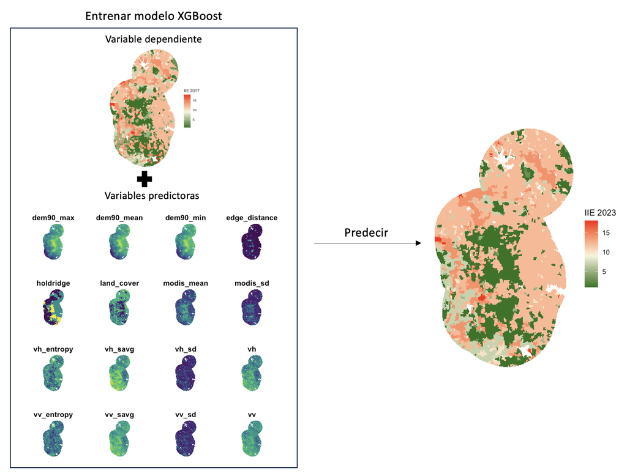

## Integridad Ecosistémica en México

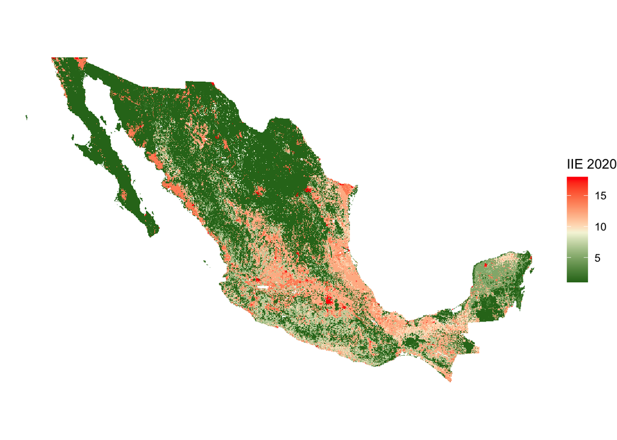

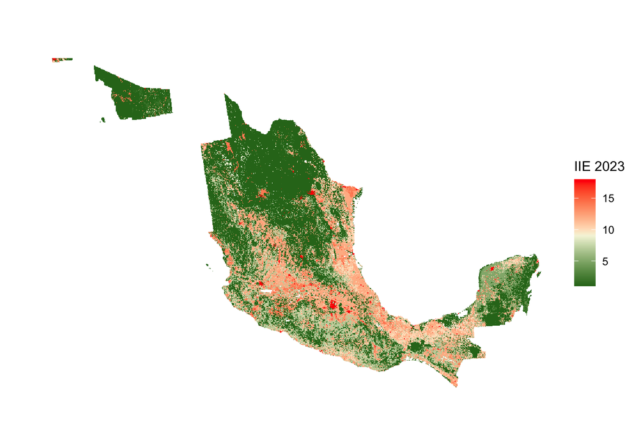

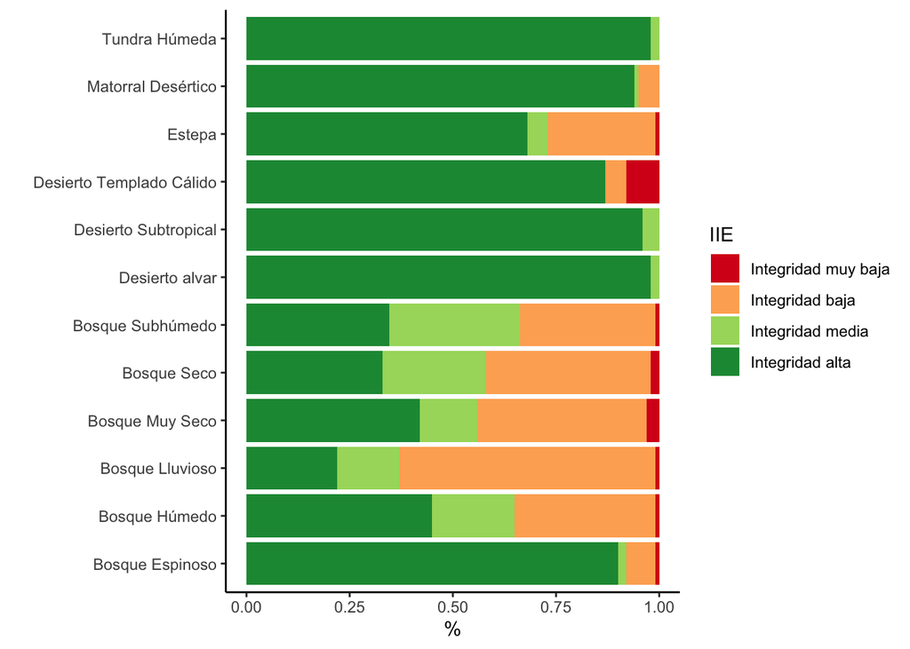

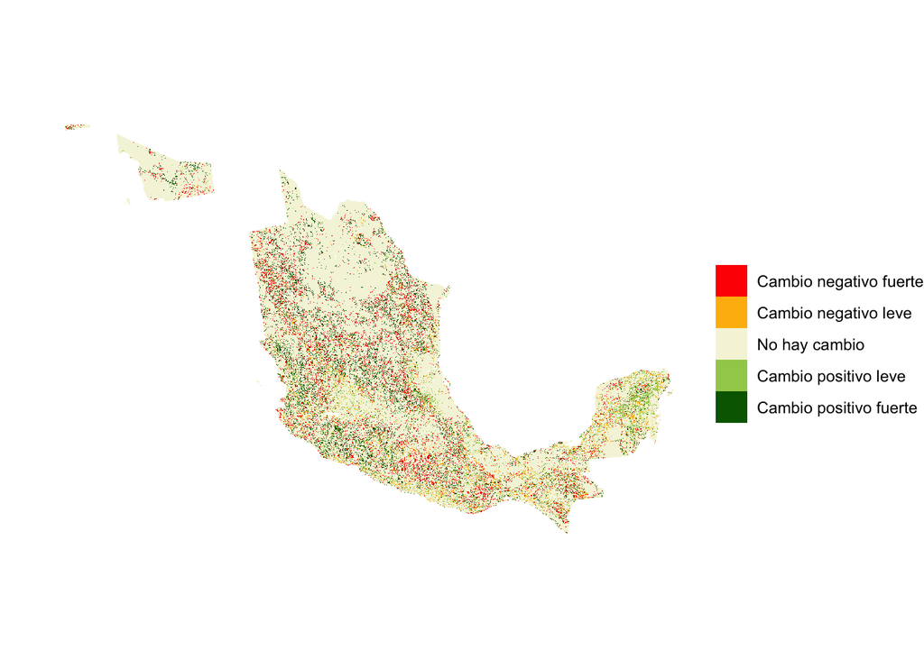

## Referencias

Di Marco, Moreno, Simon Ferrier, Tom D Harwood, Andrew J Hoskins, and James EM Watson. 2019. “Wilderness Areas Halve the Extinction Risk of Terrestrial Biodiversity.” *Nature* 573 (7775): 582–85.

Hansen, Andrew J, Benjamin P Noble, Jaris Veneros, Alyson East, Scott J Goetz, Christina Supples, James EM Watson, et al. 2021. “Toward Monitoring Forest Ecosystem Integrity Within the Post-2020 Global Biodiversity Framework.” *Conservation Letters* 14 (4): e12822.

Instituto Nacional de Estadística Geografía e Informática. 2003a. “Conjunto de Datos Vectoriales de La Carta de Uso Del Suelo y Vegetación. Escala 1:250 000. Serie VI. Conjunto Nacional.” INEGI.

———. 2003b. “Conjunto de Datos Vectoriales de La Carta de Vegetación Primaria. Escala 1: 1000000 (Niveles i y II).” INEGI.

Martin, Tara G, and James EM Watson. 2016. “Intact Ecosystems Provide Best Defence Against Climate Change.” *Nature Climate Change* 6 (2): 122–24.

Nandy, Subrata, Ritika Srinet, and Hitendra Padalia. 2021. “Mapping Forest Height and Aboveground Biomass by Integrating ICESat-2, Sentinel-1 and Sentinel-2 Data Using Random Forest Algorithm in Northwest Himalayan Foothills of India.” *Geophysical Research Letters* 48 (14): e2021GL093799.

Watson, James EM, Tom Evans, Oscar Venter, Brooke Williams, Ayesha Tulloch, Claire Stewart, Ian Thompson, et al. 2018. “The Exceptional Value of Intact Forest Ecosystems.” *Nature Ecology & Evolution* 2 (4): 599–610.

Wildlife Conservation Society. 2020. “WCS - FAQ: Ecosystem Integrity in the Post-2020 Global Biodiversity Framework.” https://cdn.wcs.org/2020/02/21/6iq1kmonow_Integrity_FAQ_2.2_21_February_2020_.pdf; WCS.